# Week 10 Assignment

## Chapter 2 Tidy Data Code (Part 2):

```r
pride_prejudice <- tidy_books %>%
  filter(book == 'Pride & Prejudice' )

afinn <- pride_prejudice %>%
  inner_join(get_sentiments('afinn')) %>%
  group_by(index = linenumber %/% 80) %>%
  summarize(sentiment = sum(value)) %>%
  mutate(method = "AFINN")
bing <- pride_prejudice %>%
  inner_join(get_sentiments('bing')) %>%
  mutate(method = "BING")
nrc <- pride_prejudice %>%
  inner_join(get_sentiments('nrc')) %>%
  filter(sentiment %in% c("positive", "negative")) %>%
  mutate(method="NRC")
```

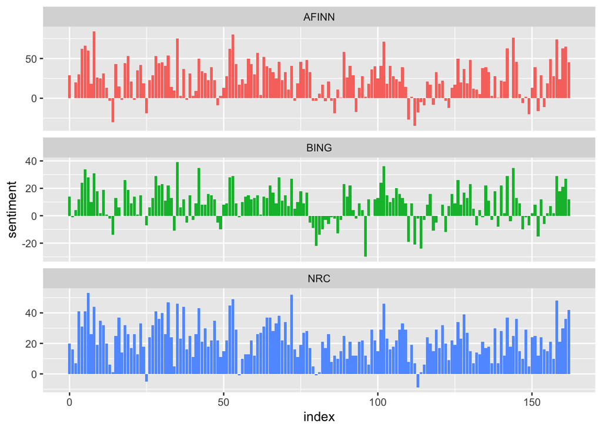

```r
bing_and_nrc <- rbind(bing,nrc) %>%
  count(method, index = linenumber %/% 80, sentiment) %>%
  spread(sentiment, n, fill=0) %>%
  mutate(sentiment = positive-negative)

bind_rows(afinn, bing_and_nrc) %>%
  ggplot(aes(index, sentiment, fill=method)) +
  geom_col(show.legend=FALSE) +
  facet_wrap(~method, ncol=1, scales="free_y")
```

## Extending Codebase: Choosing a Corpus

For this portion of the analysis, I decided to utilize the Science Fiction book “The Lost World” to evaluate the sentiment of the book.

```r
gutenberg_works() %>%
  count(gutenberg_bookshelf, sort = TRUE)
```

```
## # A tibble: 770 × 2
##    gutenberg_bookshelf                  n
##    <chr>                            <int>
##  1 <NA>                             42746
##  2 Science Fiction                   1120
##  3 Punch                              471
##  4 Children's Book Series             432
##  5 Bestsellers, American, 1895-1923   330
##  6 World War I                        307
##  7 Historical Fiction                 283
##  8 US Civil War                       265
##  9 Children's Fiction                 248
## 10 Notes and Queries                  219
## # … with 760 more rows
```

```r
gutenberg_works() %>%
  filter(gutenberg_bookshelf == 'Science Fiction') %>%
  select(title, author, gutenberg_id)
```

```
## # A tibble: 1,120 × 3
##    title                                 author                          guten…¹
##    <chr>                                 <chr>                             <int>
##  1 The Gods of Mars                      Burroughs, Edgar Rice                64
##  2 The warlord of Mars                   Burroughs, Edgar Rice                68
##  3 Thuvia, Maid of Mars                  Burroughs, Edgar Rice                72
##  4 The Monster Men                       Burroughs, Edgar Rice                96
##  5 At the Earth's Core                   Burroughs, Edgar Rice               123
##  6 The Poison Belt                       Doyle, Arthur Conan                 126
##  7 The Lost World                        Doyle, Arthur Conan                 139
##  8 The Lost Continent                    Burroughs, Edgar Rice               149
##  9 Twenty Thousand Leagues under the Sea Verne, Jules                        164
## 10 The Lost Continent                    Hyne, Charles John Cutcliffe W…     285
## # … with 1,110 more rows, and abbreviated variable name ¹gutenberg_id
```

```r
book_id <- (gutenberg_works() %>%
  select(gutenberg_id, title, author) %>%
  arrange(title) %>%
  filter(title == 'The Lost World'))$gutenberg_id

selected_book <- gutenberg_download(book_id)
```

```
## Determining mirror for Project Gutenberg from https://www.gutenberg.org/robot/harvest
```

```
## Using mirror http://aleph.gutenberg.org
```

## Extending Codebase: Sentiment Analysis using **Bing** sentiment lexicon

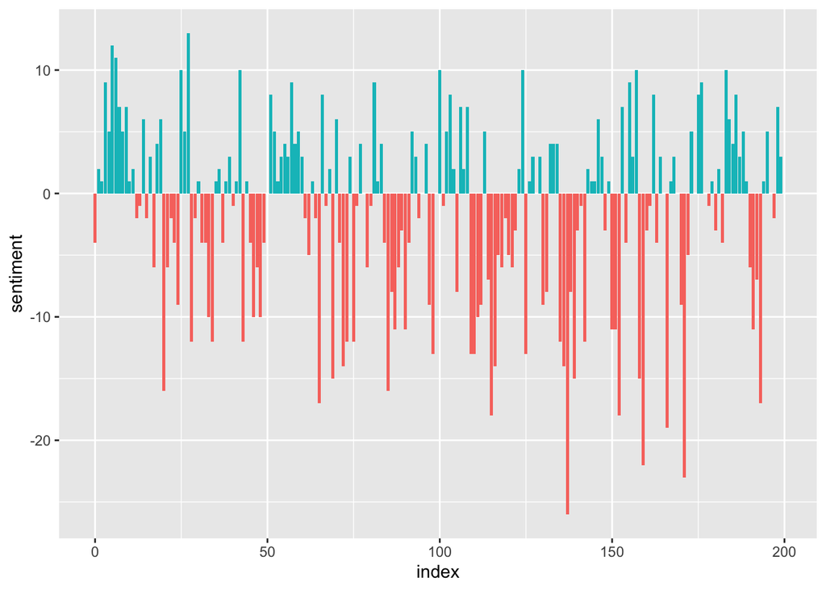

```r
tidy_book <- selected_book %>%
  mutate(linenumber = row_number(),
         chapter = cumsum(str_detect(text, "CHAPTER [\\w]+"))) %>%
  select(-gutenberg_id) %>%
  unnest_tokens(word, text)

tidy_book %>%
  mutate(index = linenumber %/% 40) %>%
  inner_join(get_sentiments('bing')) %>%
  count(index, sentiment) %>%
  spread(sentiment,n,fill=0) %>%
  mutate(sentiment = positive-negative,
         sentiment_type = ifelse(sentiment > 0, 'positive', 'negative')) %>%
  ggplot(aes(index,sentiment, fill=sentiment_type)) +
  geom_col(show.legend = FALSE)
```

## Extending Codebase: Additional Lexicons

In addition to the afinn, nrc, and bing lexicons, I also used the “loughran” lexicon. For the sections in this analysis, I used an index length of 80 lines.

```r
index_length = 80


bing <- tidy_book %>%
  mutate(index = linenumber %/% index_length) %>%
  inner_join(get_sentiments('bing')) %>%
  count(index, sentiment) %>%
  mutate(method = 'bing') %>%
  spread(sentiment,n, fill=0) %>%
  mutate(sentiment = positive-negative) %>%
  select(index, sentiment, method)
nrc <- tidy_book %>%
  mutate(index = linenumber %/% index_length) %>%
  inner_join(get_sentiments('nrc')) %>%
  filter(sentiment %in% c("positive", "negative")) %>%
  count(index, sentiment) %>%
  mutate(method = 'nrc') %>%
  spread(sentiment,n, fill=0) %>%
  mutate(sentiment = positive-negative) %>%
  select(index, sentiment, method)
loughran <- tidy_book %>%
  mutate(index = linenumber %/% index_length) %>%
  inner_join(get_sentiments('loughran')) %>%
  filter(sentiment %in% c("positive","negative")) %>%
  count(index, sentiment) %>%
  mutate(method = 'loughran') %>%
  spread(sentiment,n, fill=0) %>%
  mutate(sentiment = positive-negative) %>%
  select(index, sentiment, method)
afinn <- tidy_book %>%
  mutate(index = linenumber %/% index_length) %>%
  inner_join(get_sentiments('afinn')) %>%
  group_by(index) %>%
  summarize(sentiment = sum(value)) %>%
  mutate(method = 'afinn')
```

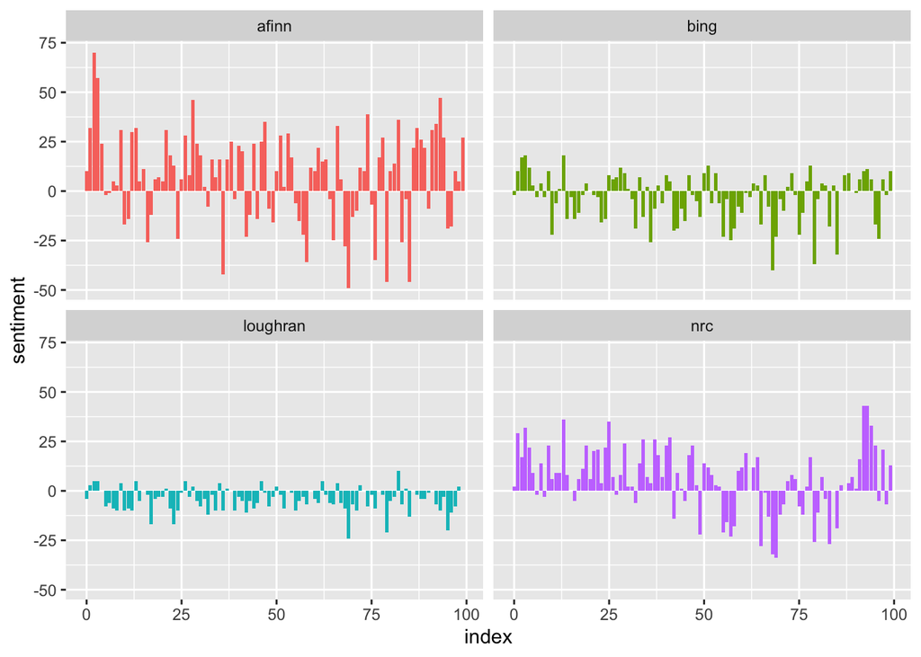

```r
rbind(loughran, nrc) %>%
  rbind(afinn) %>%
  rbind(bing) %>%
  ggplot(aes(index, sentiment, fill=method)) +
  geom_col(show.legend = FALSE) +
  facet_wrap(~method, ncol=2, nrow=2)
```

## Conclusion

This project provided a very good opportunity to explore the possibilities for conducting sentiment analysis on a corpus of text using different sentiment lexicons.